# Cumulative Snowfall

This morning I came across a cool animated map on Twitter visualizing cumulative snowfall as a shaded relief map. The author, [Garrett Dash Nelson](http://people.matinic.us/garrett/#about), posted the Python code to generate the animation in a [blog post](http://viewshed.matinic.us/). Turns out NOAA provides daily [GeoTiffs of seasonal snowfall accumulation](http://www.nohrsc.noaa.gov/snowfall/) making the production of an animated map suprisingly easy. Just for fun I thought I’d throw together a quick R version of this map.

```r
library(raster)
library(tidyverse)
library(stringr)
library(lubridate)
library(sf)
library(rnaturalearth)
library(scales)
library(viridis)
library(fields)
library(animation)
library(here)
```

## Gathering the data

I’ll start by gathering the daily GeoTiffs from the NOAA website, stack them into a single raster object, and transform to an Albers equal area projection.

```r
dl_snowfall <- function(x, dest = getwd()) {
  base_url <- sprintf("http://www.nohrsc.noaa.gov/snowfall/data/%s/",
                      format(x, "%Y%m"))
  f <- sprintf("sfav2_CONUS_2017093012_to_%s12.tif", format(x, "%Y%m%d"))
  f_dest <- file.path(dest, f)
  download.file(file.path(base_url, f), f_dest)
  return(f_dest)
}
# download files
f_snowfall <- seq(ymd("2017-10-04"), today() - 1, by = 1) %>%
  map_chr(dl_snowfall, dest = here("_source/data/snowfall/"))
# stack and transform
r_snowfall <- stack(f_snowfall)
NAvalue(r_snowfall) <- -99999
# clean up layer names
layer_dates <- names(r_snowfall) %>%
  str_extract("(?<=to_)[0-9]{8}") %>%
  ymd()
names(r_snowfall) <- paste0("snowfall_", format(layer_dates, "%Y%m%d"))
# transform and save
albers <- paste("+proj=aea +lat_1=29.5 +lat_2=45.5 +lat_0=37.5 +lon_0=-96",
                "+x_0=0 +y_0=0 +ellps=GRS80 +datum=NAD83 +units=m +no_defs")
r_file <- format(today() - 1, "%Y%m%d") %>%
  sprintf("snowfall_to_%s.grd", .) %>%
  here("_source/data/snowfall/", .)
r_snowfall <- projectRaster(2.54 * r_snowfall, crs = albers, filename = r_file,
                            overwrite = TRUE)
```

The NOAA layers originally give snowfall in inches, which I simply can’t abind, so I’ve converted them to cm.

## Hillshade

The `raster` package contains functions for produce hillshade maps to visualize elevation. Following Garrett’s lead, I’ll hijack these to visualize snowfall. I’ll start by producing a single map for the most recent date.

Instead of the simple grey hillshade in the original blog post, I’ll drape some colour over the hillshade to make things more interesting. I’ve applied a square root transform because the data are heavily right skewed. I’ll also generate the legend using the `fields` package, which allows for much more customization compared to the default `raster` plotting functions.

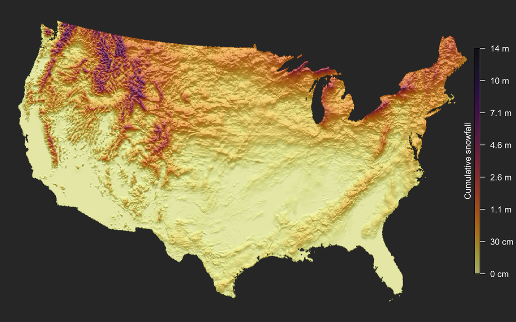

```r
r <- r_snowfall[[nlayers(r_snowfall)]]
r[r < 0] <- 0
slope <- terrain(4000 * r, opt = "slope")
aspect <- terrain(4000 * r, opt = "aspect")
hill <- hillShade(slope, aspect, angle = 40, azimuth = 315)
# us border to set plot area
states <- ne_states(iso_a2 = "US", returnclass = "sf") %>%
  filter(!postal %in% c("HI", "AK")) %>%
  st_transform(crs = projection(r)) %>%
  st_union()
# plot
# colors and legends
grey_pal <- alpha(grey(0:100 / 100), seq(-1, 1, length = 101)^2)
col_pal <- inferno(100, alpha = 0.6) %>% rev()
rng <- cellStats(r, range) %>% sqrt()
brks <- seq(rng[1], rng[2], length.out = length(col_pal) + 1)
lbls <- data_frame(at = seq(rng[1], rng[2], length.out = 8)) %>%
  mutate(lbl = at^2,
         lbl = if_else(lbl < 1000, 10 * round(lbl / 10),
                       100 * round(lbl / 100)),
         lbl = if_else(lbl < 100, paste(lbl, "cm"),
                       paste(round(lbl / 100, 2), "m")))
plot(states, border = NA, col = NA)
# hillshade
plot(hill, col = grey(0:100 / 100), maxpixels = ncell(r), legend = FALSE,
     axes = FALSE, box = FALSE, add = TRUE)
# color
plot(sqrt(r), col = col_pal, breaks = brks, maxpixels = ncell(r),
     legend = FALSE, add = TRUE)
# legend
image.plot(sqrt(r),
           col = col_pal, breaks = brks,
           zlim = rng,
           smallplot = c(0.92, 0.93, 0.15, 0.85),
           legend.only = TRUE, legend.shrink = 1, legend.width = 5,
           axis.args = list(at = lbls$at, labels = lbls$lbl,
                            fg = "white", col.axis = "white",
                            cex.axis = 1, lwd.ticks = 1),
           legend.args = list(text = "Cumulative snowfall",
                              col = "white", side = 2,
                              cex = 1, line = 0.2))
```

## Animate

Next, I produce one of these maps for each day, each will be a frame in the final animation. Note that I’ve set the legend and colour palette up to be the same for all plots in the animation.

```r
rng <- c(0, cellStats(r_snowfall, max) %>% max()) %>% sqrt()
brks <- seq(rng[1], rng[2], length.out = length(col_pal) + 1)
lbls <- data_frame(at = seq(rng[1], rng[2], length.out = 8)) %>%
  mutate(lbl = at^2,
         lbl = if_else(lbl < 1000, 10 * round(lbl / 10),
                       100 * round(lbl / 100)),
         lbl = if_else(lbl < 100, paste(lbl, "cm"),
                       paste(round(lbl / 100, 2), "m")))
# loop over layers
for (i in 1:nlayers(r_snowfall)) {
  r <- r_snowfall[[i]]
  r[r < 0] <- 0
  slope <- terrain(4000 * r, opt = "slope")
  aspect <- terrain(4000 * r, opt = "aspect")
  hill <- hillShade(slope, aspect, angle = 40, azimuth = 315)

  here("_source", "data", "snowfall", paste0(names(r_snowfall)[i], ".png")) %>%
    png(width = 2000, height = 1300, res = 400, pointsize = 8)
  par(mar = c(0, 0, 0, 1.75), bg = "grey20", lwd = 0.1)
  plot(states, border = NA, col = NA)
  # hillshade
  plot(hill, col = grey(0:100 / 100), maxpixels = ncell(r), legend = FALSE,
       axes = FALSE, box = FALSE, add = TRUE)
  # color
  plot(sqrt(r), col = col_pal, breaks = brks, maxpixels = ncell(r),
       legend = FALSE, add = TRUE)
  # legend
  image.plot(sqrt(r),
             col = col_pal, breaks = brks,
             zlim = rng,
             smallplot = c(0.93, 0.945, 0.15, 0.85),
             legend.only = TRUE, legend.shrink = 1,
             axis.args = list(at = lbls$at, labels = lbls$lbl,
                              fg = "white", col.axis = "white",
                              tck = -0.5, hadj = 0.4, lwd = NA,
                              cex.axis = 0.6, lwd.ticks = 0.5),
             legend.args = list(text = "Cumulative snowfall",
                                col = "white", side = 2,
                                cex = 0.8, line = 0.1))
  # dates
  usr <- par("usr")
  xwidth <- usr[2] - usr[1]
  yheight <- usr[4] - usr[3]
  # labels
  month_pos <- seq(0.05, 1 - 0.05, length.out = 5)
  names(month_pos) <- c("Oct", "Nov", "Dec", "Jan", "Feb")
  for (j in seq_along(month_pos)) {
    text(x = usr[1] + month_pos[j] * xwidth, y = usr[3] + 0.05 * yheight,
       labels = names(month_pos)[j],
       cex = 0.8, col = "white")
  }
  # lines
  dt <- str_extract(names(r), "[0-9]{8}") %>%
    ymd()
  mth <- days_in_month(dt)
  mth_idx <- which(names(month_pos) %in% names(mth))
  bar_col <- viridis(nlayers(r_snowfall))[i]
  for (j in 1:(length(month_pos) - 1)) {
    mth_start_x <- month_pos[j] + 0.025
    mth_end_x <- month_pos[j + 1] - 0.025
    if (j < mth_idx) {
      lines(x = usr[1] + xwidth * c(mth_start_x, mth_end_x),
            y = c(0.05, 0.05) * yheight + usr[3],
            col = bar_col, lwd = 2)
    } else if (j > mth_idx) {
      lines(x = usr[1] + xwidth * c(mth_start_x, mth_end_x),
            y = c(0.05, 0.05) * yheight + usr[3],
            col = "white", lwd = 2)
    } else {
      mth_pct_cmplt <- (day(dt) - 1) / mth
      mth_abs_cmplt <- (mth_end_x - mth_start_x) * mth_pct_cmplt
      brk_pt <- mth_start_x + mth_abs_cmplt
      lines(x = usr[1] + xwidth * c(brk_pt, mth_end_x),
            y = c(0.05, 0.05) * yheight + usr[3],
            col = "white", lwd = 2)
      lines(x = usr[1] + xwidth * c(mth_start_x, brk_pt),
            y = c(0.05, 0.05) * yheight + usr[3],
            col = bar_col, lwd = 2)
    }
  }
  dev.off()
}
```

Finally, I combine all these frames together into a single GIF animation using the `animation` package, which interfaces with the ImageMagick command line utility.

```r
frames <- here("_source", "data", "snowfall") %>%
  list.files("png$", full.names = TRUE) %>%
  sort()
f_animation <- here("_source", "data", "snowfall", "snowfall_to_20180112.gif")
ani.options(interval = 0.1)
im.convert(frames, f_animation, extra.opts = "-resize 50%")
```

[output not shown]

[output cut: 49 more lines]

[output not shown]

```
## Output at: /Users/mes335/projects/mstrimas.github.io/_source/data/snowfall/snowfall_to_20180112.gif
```

[img/snowfall/snowfall_to_20180112.gif]